# Data Populasi USA

G1401211038_Dhiya Khalishah Tsany Suwarso

2023-10-30

### Packages

```r
library(ggplot2)
library(tsibble)
library(tseries)
library(MASS)
library(forecast)
library(TSA)
library(TTR)
library(aTSA)
library(graphics)
```

### Input Data yang akan digunakan

Data yang digunakan adalah Populasi Amerika Serikat bulanan mulai bulan Januari 1965 - Agustus 2023 dengan total 704 periode

```r
library(readxl)
data <- read_excel('C:/Users/Windi Gunawan/Downloads/Population United States.xlsx')
data.ts <- ts(data$Population)
```

### Eksplorasi Data

#### Plot Data Penuh

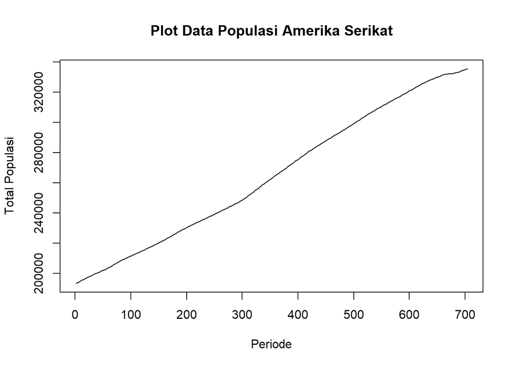

```r
plot.ts(data.ts, lty=1, xlab="Periode", ylab="Total Populasi", main="Plot Data Populasi Amerika Serikat")
```

Berdasarkan plot data deret waktu, terlihat bahwa data cenderung memiliki trend yang naik. Berdasarkan pola data, pembagian data latih dan data uji ditetapkan dengan proporsi 80%:20% sehingga 563 periode untuk data latih dan 141 periode untuk data uji.

#### Plot Data Latih

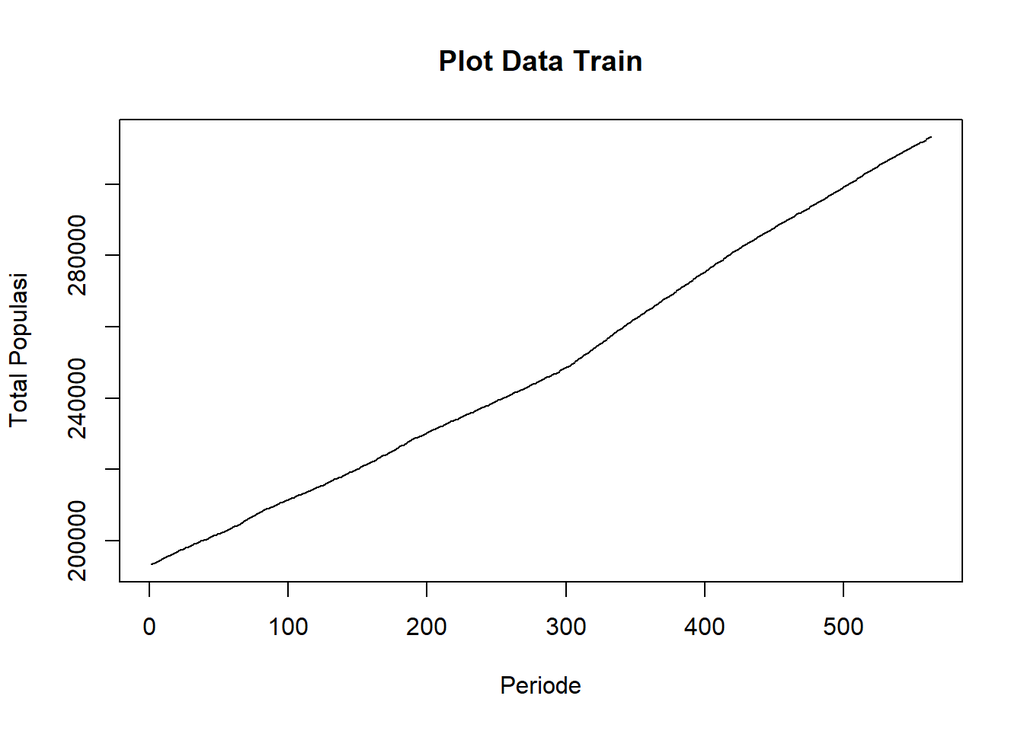

```r
datatrain<-data$Population[1:563]
train.ts<-ts(datatrain)
plot.ts(train.ts, lty=1, xlab="Periode", ylab="Total Populasi", main="Plot Data Train")
```

Berdasarkan plot data deret waktu pada data latih, terlihat bahwa data cenderung memiliki trend yang naik dan cenderung tidak bergerak pada nilai tengah tertentu. Hal ini mengindikasikan bahwa data tidak stasioner dalam rataan.

#### Plot Data Uji

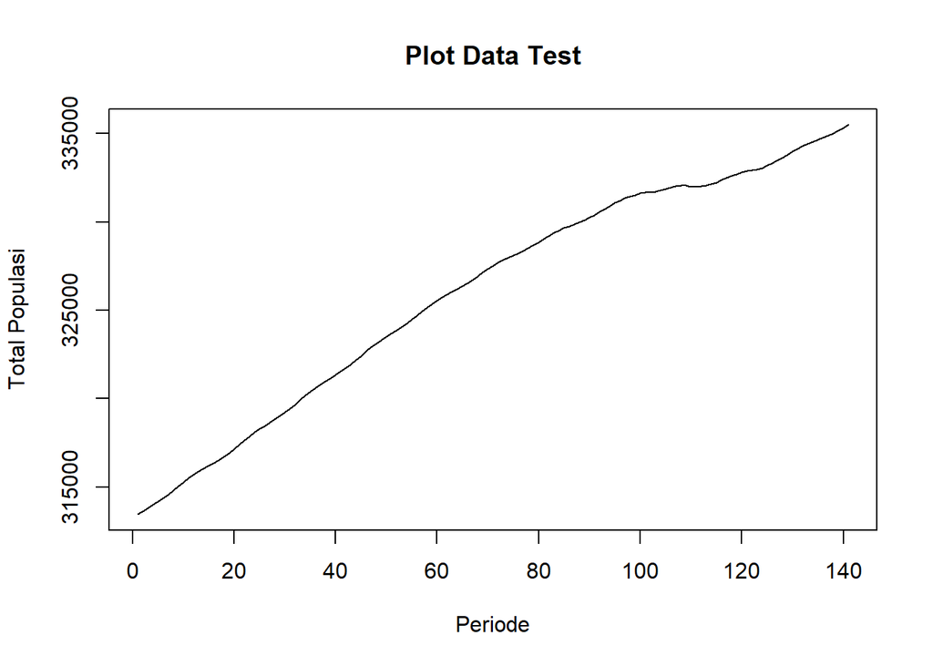

```r
datatest<-data$Population[564:704]
test.ts<-ts(datatest)
plot.ts(test.ts, lty=1, xlab="Periode", ylab="Total Populasi", main="Plot Data Test")
```

Berdasarkan plot data deret waktu pada data uji, terlihat bahwa data cenderung memiliki trend yang naik dan cenderung tidak bergerak pada nilai tengah tertentu. Hal ini mengindikasikan bahwa data tidak stasioner dalam rataan.

### Uji Stasioneritas Data

#### Plot ACF

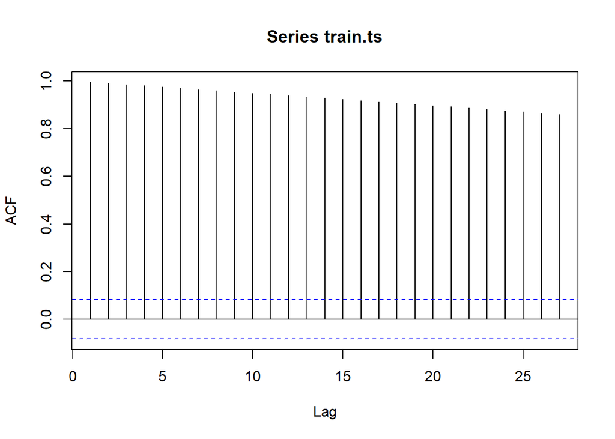

```r
acf(train.ts)
```

Berdasarkan plot ACF, terlihat bahwa plot ACF data menurun secara perlahan (*tails of slowly*). Hal ini juga menjadi indikasi bahwa data tidak stasioner dalam rataan.

#### Uji ADF

```r
tseries::adf.test(train.ts)
```

```
##
##  Augmented Dickey-Fuller Test
##
## data:  train.ts
## Dickey-Fuller = -2.4125, Lag order = 8, p-value = 0.4037
## alternative hypothesis: stationary
```

$H_0$ : Data tidak stasioner dalam rataan

$H_1$ : Data stasioner dalam rataan

Berdasarkan uji ADF tersebut, didapat *p-value* sebesar 0.4037 yang lebih besar dari taraf nyata 5% sehingga tak tolak $H_0$ dan menandakan bahwa data tidak stasioner dalam rataan. Hal ini sesuai dengan hasil eksplorasi menggunakan plot time series dan plot ACF, sehingga ketidakstasioneran model kedepannya harus ditangani.

#### Plot Box-Cox

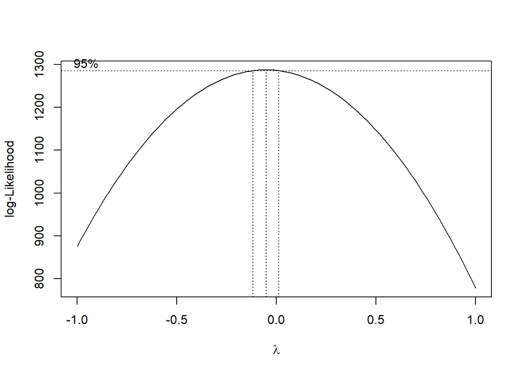

```r
index <- seq(1:563)
bc = boxcox(train.ts~index, lambda = seq(-1,1,by=1))
```

```r
#Nilai Rounded Lambda
lambda <- bc$x[which.max(bc$y)]
lambda
```

```
## [1] -0.05050505
```

```r
#SK
bc$x[bc$y > max(bc$y) - 1/2 * qchisq(.95,1)]
```

```
## [1] -0.11111111 -0.09090909 -0.07070707 -0.05050505 -0.03030303 -0.01010101
## [7]  0.01010101
```

Plot Boxcox menunjukkan nilai *rounded value* ($\lambda$) optimum sebesar **-0.05050505** dan pada selang kepercayaan 95% nilai memiliki batas bawah **-0.11111111** dan batas atas **0.01010101**. Selang tersebut tidak memuat nilai satu sehingga dapat dikatakan bahwa data tidak stasioner dalam ragam.

### Penanganan Ketidakstasioneran Data

### Differencing 1

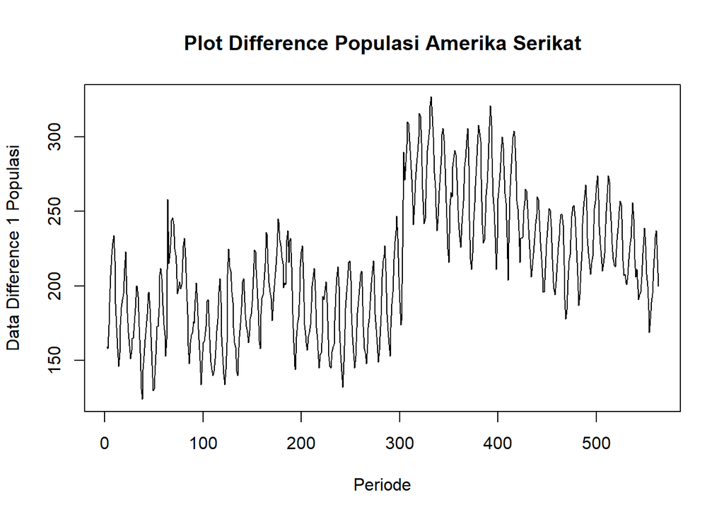

```r
train.diff<-diff(train.ts,differences = 1)
plot.ts(train.diff, lty=1, xlab="Periode", ylab="Data Difference 1 Populasi", main="Plot Difference Populasi Amerika Serikat")
```

Berdasarkan plot data deret waktu, terlihat bahwa data belum stasioner dalam rataan.

#### Uji ADF

```r
tseries::adf.test(train.diff)
```

```
##
##  Augmented Dickey-Fuller Test
##
## data:  train.diff
## Dickey-Fuller = -1.6519, Lag order = 8, p-value = 0.7256
## alternative hypothesis: stationary
```

$H_0$ : Data tidak stasioner dalam rataan

$H_1$ : Data stasioner dalam rataan

Berdasarkan uji ADF tersebut, didapat *p-value* sebesar 0.7256 yang lebih besar dari taraf nyata 5% sehingga tak tolak $H_0$ atau data tidak stasioner dalam rataan. Hal ini sesuai dengan hasil eksplorasi menggunakan plot time series data difference 1 populasi.

### Differencing 2

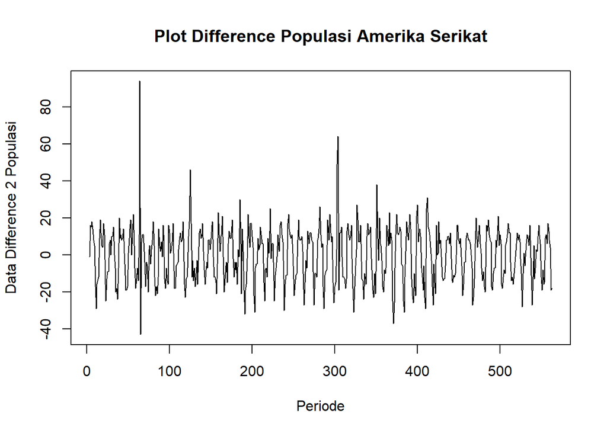

```r
train.diff2<-diff(train.ts,differences = 2)
plot.ts(train.diff2, lty=1, xlab="Periode", ylab="Data Difference 2 Populasi", main="Plot Difference Populasi Amerika Serikat")
```

Berdasarkan plot data deret waktu, terlihat bahwa data sudah stasioner dalam rataan ditandai dengan data bergerak pada nilai tengah tertentu.

#### Plot ACF

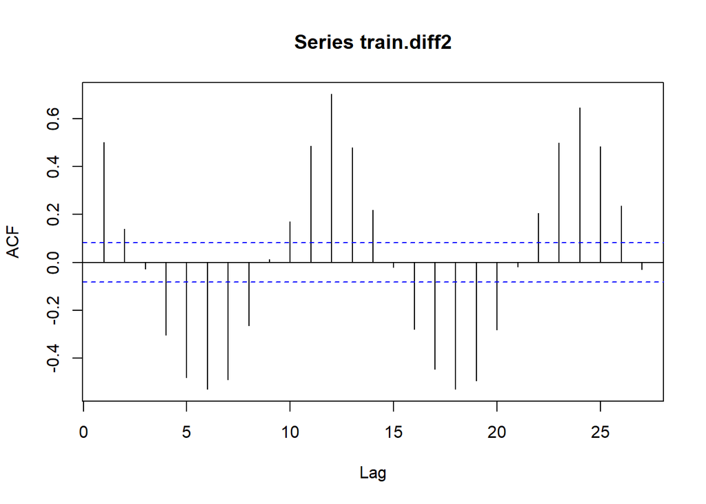

```r
acf(train.diff2)
```

#### Uji ADF

```r
tseries::adf.test(train.diff2)
```

```
##
##  Augmented Dickey-Fuller Test
##
## data:  train.diff2
## Dickey-Fuller = -17.084, Lag order = 8, p-value = 0.01
## alternative hypothesis: stationary
```

$H_0$ : Data tidak stasioner dalam rataan

$H_1$ : Data stasioner dalam rataan

Berdasarkan uji ADF tersebut, didapat *p-value* sebesar 0.01 yang lebih kecil dari taraf nyata 5% sehingga tolak $H_0$ atau data stasioner dalam rataan. Hal ini sesuai dengan hasil eksplorasi menggunakan plot time series dan plot ACF, sehingga dalam hal ini ketidakstasioneran data sudah berhasil ditangani dan dapat dilanjutkan ke pemodelan

### Identifikasi Model

#### Plot ACF

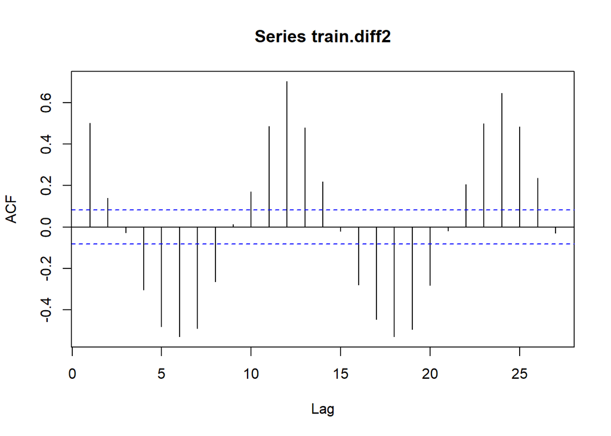

```r
acf(train.diff2)
```

#### Plot PACF

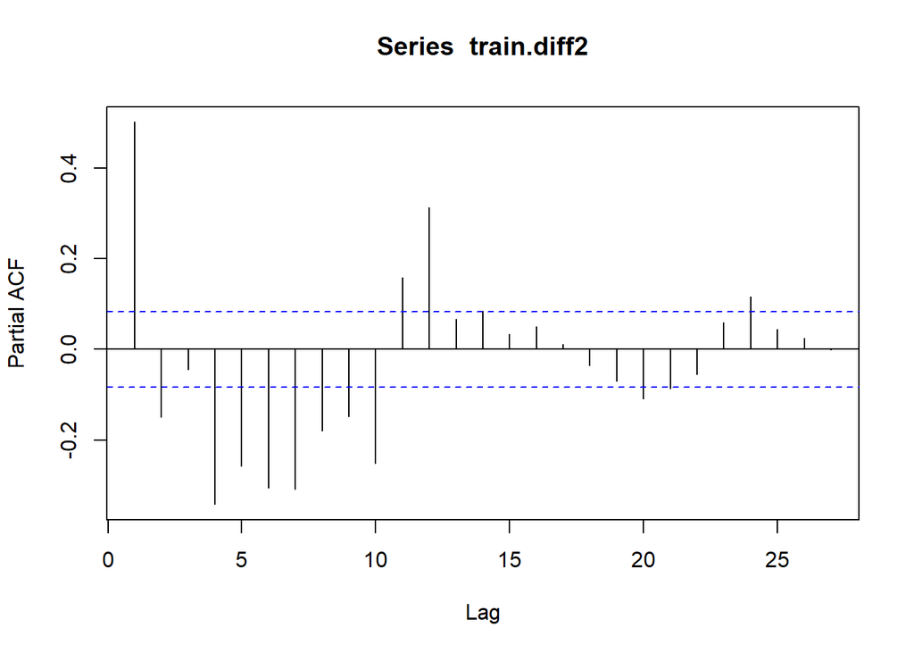

```r
pacf(train.diff2)
```

Jika baik plot ACF maupun plot PACF keduanya dianggap tails off, maka model yang terbentuk adalah ARIMA(2,2,2).

#### Plot EACF

```r
eacf(train.diff2)
```

```
## AR/MA
##   0 1 2 3 4 5 6 7 8 9 10 11 12 13
## 0 x x o x x x x x o x x  x  x  x
## 1 x x o x x x x x o o x  x  x  x
## 2 x o x o o o x o x o o  x  x  o
## 3 x x x x o o x o x x o  x  x  x
## 4 x x x x o o o o o x o  x  x  x
## 5 x x o x o o o o o x o  x  x  x
## 6 x x x o x o o o o o o  x  x  o
## 7 x x x o x o x o o o o  x  x  x
```

Identifikasi model menggunakan plot EACF dilakukan dengan melihat ujung segitiga pada pola segitiga nol. Dalam hal ini model tentatif yang terbentuk adalah ARIMA(2,2,3).

### Pendugaan Parameter Model Tentatif

#### ARIMA(0,2,2)

```r
model1.da=Arima(train.diff2, order=c(0,2,2),method="ML")
summary(model1.da) #AIC=4588.29
```

```
## Series: train.diff2
## ARIMA(0,2,2)
##
## Coefficients:
##           ma1     ma2
##       -1.2158  0.2158
## s.e.   0.0511  0.0509
##
## sigma^2 = 210.8:  log likelihood = -2291.14
## AIC=4588.29   AICc=4588.33   BIC=4601.26
##
## Training set error measures:
##                       ME     RMSE      MAE MPE MAPE     MASE       ACF1
## Training set -0.08217144 14.46577 10.29741 NaN  Inf 1.016132 0.03620114
```

```r
lmtest::coeftest(model1.da) #seluruh parameter signifikan
```

```
##
## z test of coefficients:
##
##      Estimate Std. Error  z value  Pr(>|z|)
## ma1 -1.215793   0.051138 -23.7746 < 2.2e-16 ***
## ma2  0.215794   0.050942   4.2361 2.275e-05 ***
## ---
## Signif. codes:  0 '***' 0.001 '**' 0.01 '*' 0.05 '.' 0.1 ' ' 1
```

#### ARIMA(2,2,0)

```r
model2.da=Arima(train.diff2, order=c(2,2,0),method="ML")
summary(model2.da) #AIC=4755.95
```

```
## Series: train.diff2
## ARIMA(2,2,0)
##
## Coefficients:
##           ar1      ar2
##       -0.7123  -0.4971
## s.e.   0.0367   0.0367
##
## sigma^2 = 287.6:  log likelihood = -2374.98
## AIC=4755.95   AICc=4755.99   BIC=4768.93
##
## Training set error measures:
##                       ME     RMSE     MAE MPE MAPE     MASE       ACF1
## Training set -0.08158154 16.89729 11.7095 NaN  Inf 1.155475 -0.1038237
```

```r
lmtest::coeftest(model2.da) #seluruh parameter signifikan
```

```
##
## z test of coefficients:
##
##      Estimate Std. Error z value  Pr(>|z|)
## ar1 -0.712267   0.036706 -19.405 < 2.2e-16 ***
## ar2 -0.497059   0.036656 -13.560 < 2.2e-16 ***
## ---
## Signif. codes:  0 '***' 0.001 '**' 0.01 '*' 0.05 '.' 0.1 ' ' 1
```

#### ARIMA(2,2,2)

```r
model3.da=Arima(train.diff2, order=c(2,2,2),method="ML")
summary(model3.da) #AIC=4568.56
```

```
## Series: train.diff2
## ARIMA(2,2,2)
##
## Coefficients:
##           ar1      ar2     ma1      ma2
##       -0.5352  -0.2628  -0.610  -0.3900
## s.e.   0.1504   0.0413   0.155   0.1549
##
## sigma^2 = 202.7:  log likelihood = -2279.28
## AIC=4568.56   AICc=4568.67   BIC=4590.19
##
## Training set error measures:
##                       ME     RMSE      MAE MPE MAPE      MASE         ACF1
## Training set -0.08047946 14.16053 10.05199 NaN  Inf 0.9919141 -0.001798224
```

```r
lmtest::coeftest(model3.da) #seluruh parameter signifikan
```

```
##
## z test of coefficients:
##
##      Estimate Std. Error z value  Pr(>|z|)
## ar1 -0.535225   0.150399 -3.5587 0.0003727 ***
## ar2 -0.262845   0.041256 -6.3710 1.877e-10 ***
## ma1 -0.610038   0.154977 -3.9363 8.275e-05 ***
## ma2 -0.389962   0.154922 -2.5172 0.0118308 *
## ---
## Signif. codes:  0 '***' 0.001 '**' 0.01 '*' 0.05 '.' 0.1 ' ' 1
```

#### ARIMA(2,2,3)

```r
model4.da=Arima(train.diff2, order=c(2,2,3),method="ML")
summary(model4.da) #AIC=4447.52
```

```
## Series: train.diff2
## ARIMA(2,2,3)
##
## Coefficients:
##           ar1     ar2      ma1      ma2     ma3
##       -0.1909  0.2760  -1.2215  -0.5542  0.7763
## s.e.   0.0890  0.0669   0.0693   0.1378  0.0694
##
## sigma^2 = 160.2:  log likelihood = -2217.76
## AIC=4447.52   AICc=4447.67   BIC=4473.48
##
## Training set error measures:
##                      ME     RMSE      MAE MPE MAPE      MASE      ACF1
## Training set 0.06767936 12.57739 9.081725 NaN  Inf 0.8961702 0.0112534
```

```r
lmtest::coeftest(model4.da) #seluruh parameter signifikan
```

```
##
## z test of coefficients:
##
##      Estimate Std. Error  z value  Pr(>|z|)
## ar1 -0.190850   0.088991  -2.1446   0.03199 *
## ar2  0.276037   0.066888   4.1269 3.678e-05 ***
## ma1 -1.221516   0.069317 -17.6220 < 2.2e-16 ***
## ma2 -0.554214   0.137792  -4.0221 5.768e-05 ***
## ma3  0.776315   0.069419  11.1830 < 2.2e-16 ***
## ---
## Signif. codes:  0 '***' 0.001 '**' 0.01 '*' 0.05 '.' 0.1 ' ' 1
```

Berdasarkan pendugaan parameter di atas, nilai AIC terkecil dimiliki oleh model ARIMA(2,2,3) dengan nilai AIC sebesar 4447.52 dan seluruh parameternya signifikan sehingga model yang dipilih adalah model ARIMA(2,2,3).

### Analisis Sisaan

Model terbaik hasil identifikasi kemudian dicek asumsi sisaannya. Sisaan model ARIMA harus memenuhi asumsi normalitas, kebebasan sisaan, dan kehomogenan ragam. Diagnostik model dilakukan secara eksplorasi dan uji formal.

#### Eksplorasi Sisaan

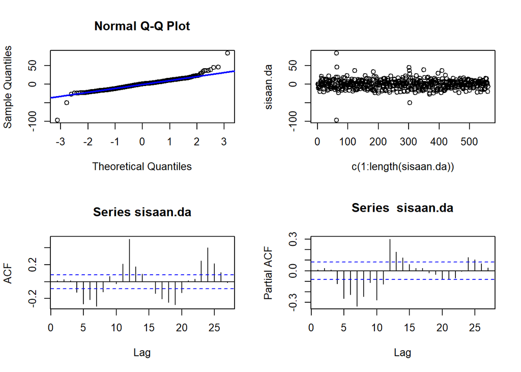

```r
#Eksplorasi
sisaan.da <- model4.da$residuals
par(mfrow=c(2,2))
qqnorm(sisaan.da)
qqline(sisaan.da, col = "blue", lwd = 2)
plot(c(1:length(sisaan.da)),sisaan.da)
acf(sisaan.da)
pacf(sisaan.da)
```

```r
par(mfrow = c(1,1))
```

Berdasarkan plot kuantil-kuantil normal, secara eksplorasi ditunjukkan sisaan tidak menyebar normal ditandai dengan titik titik yang cenderung tidak mengikuti garis. Kemudian dapat dilihat juga lebar pita sisaan yang cenderung tidak sama menandakan bahwa sisaan memiliki ragam yang heterogen. Plot ACF dan PACF sisaan ARIMA(2,2,3) signifikan pada lag ke-4 sehingga sisaan tidak saling bebas. Kondisi ini akan diuji lebih lanjut dengan uji formal.

#### Uji Formal

```r
#1) Sisaan Menyebar Normal
ks.test(sisaan.da,"pnorm")  #tak tolak H0 > sisaan menyebar normal
```

```
##
##  Asymptotic one-sample Kolmogorov-Smirnov test
##
## data:  sisaan.da
## D = 0.42672, p-value < 2.2e-16
## alternative hypothesis: two-sided
```

Selain dengan eksplorasi, asumsi tersebut dapat diuji menggunakan uji formal. Pada tahapan ini uji formal yang digunakan untuk normalitas adalah uji Kolmogorov-Smirnov (KS). Hipotesis pada uji KS adalah sebagai berikut.

$H_0$ : Sisaan menyebar normal

$H_1$ : Sisaan tidak menyebar normal

Berdasarkan uji KS tersebut, didapat *p-value* sebesar < 2.2e-16 yang kurang dari taraf nyata 5% sehingga tolak $H_0$ dan menandakan bahwa sisaan tidak menyebar normal. Hal ini sesuai dengan hasil eksplorasi menggunakan plot kuantil-kuantil normal.

```r
#2) Sisaan saling bebas/tidak ada autokorelasi
Box.test(sisaan.da, type = "Ljung")  #tak tolak H0 > sisaan saling bebas
```

```
##
##  Box-Ljung test
##
## data:  sisaan.da
## X-squared = 0.071425, df = 1, p-value = 0.7893
```

Selanjutnya akan dilakukan uji formal untuk kebebasan sisaan menggunakan uji Ljung-Box. Hipotesis yang digunakan adalah sebagai berikut.

$H_0$ : Sisaan saling bebas

$H_1$ : Sisaan tidak tidak saling bebas

Berdasarkan uji Ljung-Box tersebut, didapat *p-value* sebesar 0.7893 yang lebih besar dari taraf nyata 5% sehingga tak tolak $H_0$ dan menandakan bahwa sisaan saling bebas. Hal ini berbeda dengan eksplorasi.

```r
#3) Sisaan homogen
Box.test((sisaan.da)^2, type = "Ljung")  #tak tolak H0 > sisaan homogen
```

```
##
##  Box-Ljung test
##
## data:  (sisaan.da)^2
## X-squared = 171.61, df = 1, p-value < 2.2e-16
```

Hipotesis yang digunakan untuk uji kehomogenan ragam adalah sebagai berikut.

$H_0$ : Ragam sisaan homogen

$H_1$ : Ragam sisaan tidak homogen

Berdasarkan uji Ljung-Box terhadap sisaan kuadrat tersebut, didapat *p-value* sebesar < 2.2e-16 yang kurang dari taraf nyata 5% sehingga tolak $H_0$ dan menandakan bahwa ragam sisaan tidak homogen.

```r
#4) Nilai tengah sisaan sama dengan nol
t.test(sisaan.da, mu = 0, conf.level = 0.95)  #tak tolak h0 > nilai tengah sisaan sama dengan 0
```

```
##
##  One Sample t-test
##
## data:  sisaan.da
## t = 0.12734, df = 560, p-value = 0.8987
## alternative hypothesis: true mean is not equal to 0
## 95 percent confidence interval:
##  -0.9762668  1.1116256
## sample estimates:
##  mean of x
## 0.06767936
```

Terakhir, dengan uji-t, akan dicek apakah nilai tengah sisaan sama dengan nol. Hipotesis yang diujikan sebagai berikut.

$H_0$ : nilai tengah sisaan sama dengan 0

$H_1$ : nilai tengah sisaan tidak sama dengan 0

Berdasarkan uji-ttersebut, didapat *p-value* sebesar 0.8987 yang lebih besar dari taraf nyata 5% sehingga tak tolak $H_0$ dan menandakan bahwa nilai tengah sisaan sama dengan nol.

### Overfitting

Tahapan selanjutnya adalah overfitting dilakukan dengan menaikkan orde AR(p) dan MA(q) dari model ARIMA(2,2,3) untuk melihat apakah terdapat model lain yang lebih baik dari model saat ini. Kandidat model overfitting adalah ARIMA(3,2,3) dan ARIMA(2,2,4).

#### ARIMA(3,2,3)

```r
model5.da=Arima(train.diff2, order=c(3,2,3),method="ML")
summary(model5.da) #AIC=4449.51
```

```
## Series: train.diff2
## ARIMA(3,2,3)
##
## Coefficients:
##           ar1     ar2      ar3      ma1      ma2     ma3
##       -0.1832  0.2533  -0.0531  -1.2169  -0.5507  0.7682
## s.e.   0.1646  0.1092   0.0615   0.1546   0.3060  0.1519
##
## sigma^2 = 161.1:  log likelihood = -2217.76
## AIC=4449.51   AICc=4449.72   BIC=4479.8
##
## Training set error measures:
##                      ME     RMSE     MAE MPE MAPE      MASE        ACF1
## Training set 0.07145449 12.60321 9.14573 NaN  Inf 0.9024861 -0.00167585
```

```r
lmtest::coeftest(model5.da) #terdapat parameter tidak signifikan
```

```
##
## z test of coefficients:
##
##      Estimate Std. Error z value  Pr(>|z|)
## ar1 -0.183227   0.164639 -1.1129   0.26575
## ar2  0.253288   0.109167  2.3202   0.02033 *
## ar3 -0.053149   0.061509 -0.8641   0.38754
## ma1 -1.216928   0.154562 -7.8734 3.451e-15 ***
## ma2 -0.550674   0.306025 -1.7994   0.07195 .
## ma3  0.768229   0.151936  5.0563 4.276e-07 ***
## ---
## Signif. codes:  0 '***' 0.001 '**' 0.01 '*' 0.05 '.' 0.1 ' ' 1
```

#### ARIMA(2,2,4)

```r
model6.da=Arima(train.diff2, order=c(2,2,4),method="ML")
summary(model6.da) #AIC=4449.3
```

```
## Series: train.diff2
## ARIMA(2,2,4)
##
## Coefficients:
##           ar1     ar2      ma1      ma2     ma3     ma4
##       -0.3692  0.2280  -1.0312  -0.7937  0.6837  0.1422
## s.e.   0.1270  0.0712   0.1188   0.1785  0.0805  0.0737
##
## sigma^2 = 160.3:  log likelihood = -2217.65
## AIC=4449.3   AICc=4449.51   BIC=4479.59
##
## Training set error measures:
##                     ME     RMSE      MAE MPE MAPE      MASE         ACF1
## Training set 0.1046638 12.57127 9.104704 NaN  Inf 0.8984377 -0.005571042
```

```r
lmtest::coeftest(model6.da) #terdapat parameter tidak signifikan
```

```
##
## z test of coefficients:
##
##      Estimate Std. Error z value  Pr(>|z|)
## ar1 -0.369224   0.127016 -2.9069  0.003650 **
## ar2  0.228008   0.071246  3.2003  0.001373 **
## ma1 -1.031212   0.118825 -8.6784 < 2.2e-16 ***
## ma2 -0.793701   0.178535 -4.4456 8.764e-06 ***
## ma3  0.683693   0.080494  8.4937 < 2.2e-16 ***
## ma4  0.142178   0.073679  1.9297  0.053645 .
## ---
## Signif. codes:  0 '***' 0.001 '**' 0.01 '*' 0.05 '.' 0.1 ' ' 1
```

Berdasarkan kedua model hasil overfitting di atas, model ARIMA(3,2,3) dan ARIMA(2,2,4) memiliki AIC yang lebih besar dibandingkan dengan model ARIMA(2,2,3) dan parameter kedua model ARIMA(3,2,3) dan ARIMA(2,2,4) tidak seluruhnya signifikan. Oleh karena itu, model ARIMA(2,2,3) akan tetap digunakan untuk melakukan peramalan.

### Peramalan

Peramalan dilakukan menggunakan fungsi `forecast()` . Contoh peramalan berikut ini dilakukan untuk 141 periode ke depan.

```r
#---FORECAST---#
ramalan.da <- forecast::forecast(model4.da, h = 141)
ramalan.da
```

```
##     Point Forecast     Lo 80     Hi 80     Lo 95    Hi 95
## 564      -7.882275 -24.12235  8.357803 -32.71933 16.95478
## 565      -4.621233 -23.47796 14.235495 -33.46011 24.21764
## 566      -2.450014 -21.50898 16.608955 -31.59819 26.69816
## 567      -1.963502 -21.15380 17.226796 -31.31253 27.38553
## 568      -1.456295 -20.65228 17.739690 -30.81402 27.90143
## 569      -1.418080 -20.62577 17.789609 -30.79371 27.95755
## 570      -1.284645 -20.49286 17.923572 -30.66108 28.09179
## 571      -1.298843 -20.50962 17.911939 -30.67920 28.08151
## 572      -1.258580 -20.46989 17.952734 -30.63975 28.12259
## 573      -1.269463 -20.48220 17.943278 -30.65281 28.11389
## 574      -1.255552 -20.46914 17.958034 -30.64020 28.12909
## 575      -1.260491 -20.47540 17.954420 -30.64716 28.12618
## 576      -1.254989 -20.47107 17.961097 -30.64346 28.13348
## 577      -1.256682 -20.47424 17.960872 -30.64739 28.13403
```

[output cut: 127 more lines]

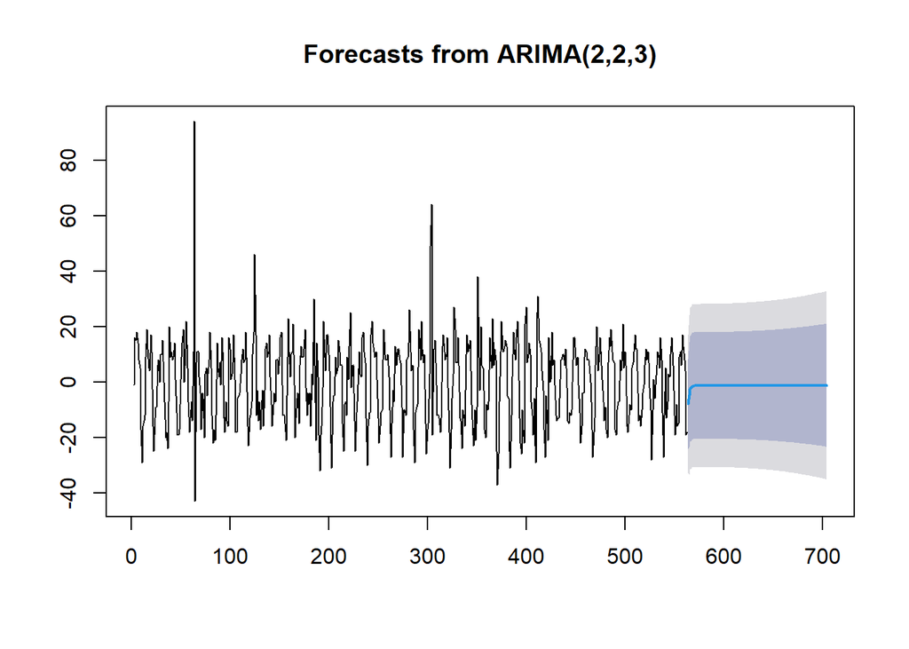

```r
data.ramalan.da <- ramalan.da$mean
plot(ramalan.da)
```

Berdasarkan hasil plot ramalan di atas, dapat dilihat bahwa ramalan ARIMA(2,2,3) cenderung stabil hingga akhir periode. Selanjutnya, dapat dicari nilai akurasi antara hasil ramalan dengan data uji sebagai berikut.

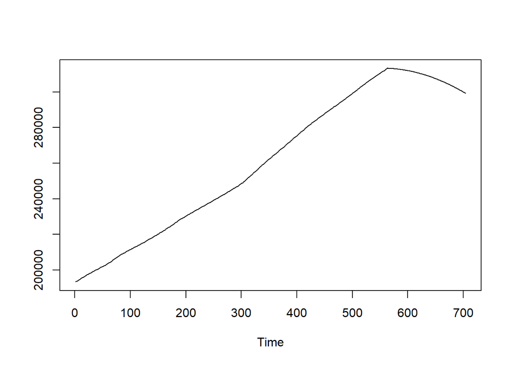

```r
pt_1 <- train.ts[563] #nilai akhir data latih
hasil.forc.Diff <- data.ramalan.da
hasil <- diffinv(hasil.forc.Diff, differences = 2) + pt_1
#has.1 sama hasilnya dengan: cumsum(c(pt_1,hasil.forc.Diff))
ts.plot(train.ts,hasil)
```

```r
perbandingan.da<-matrix(data=c(head(test.ts, n=141), hasil[-c(1,2)]),
                     nrow = 141, ncol = 2)
colnames(perbandingan.da)<-c("Aktual","Hasil Forecast")
perbandingan.da
```

```
##        Aktual Hasil Forecast
##   [1,] 313454       313252.1
##   [2,] 313636       313239.6
##   [3,] 313811       313224.7
##   [4,] 313993       313207.7
##   [5,] 314176       313189.4
##   [6,] 314368       313169.6
##   [7,] 314576       313148.5
##   [8,] 314796       313126.1
##   [9,] 315031       313102.5
##  [10,] 315264       313077.6
##  [11,] 315485       313051.4
##  [12,] 315692       313024.0
##  [13,] 315877       312995.3
##  [14,] 316038       312965.4
```

[output cut: 127 more lines]

```r
accuracy(ts(hasil[-c(1,2)]), head(test.ts, n=141))
```

```
##                ME     RMSE      MAE      MPE     MAPE      ACF1 Theil's U
## Test set 17876.47 20729.87 17876.47 5.420547 5.420547 0.9787493  120.5541
```

### Penanganan ketidakstasioneran dalam Ragam

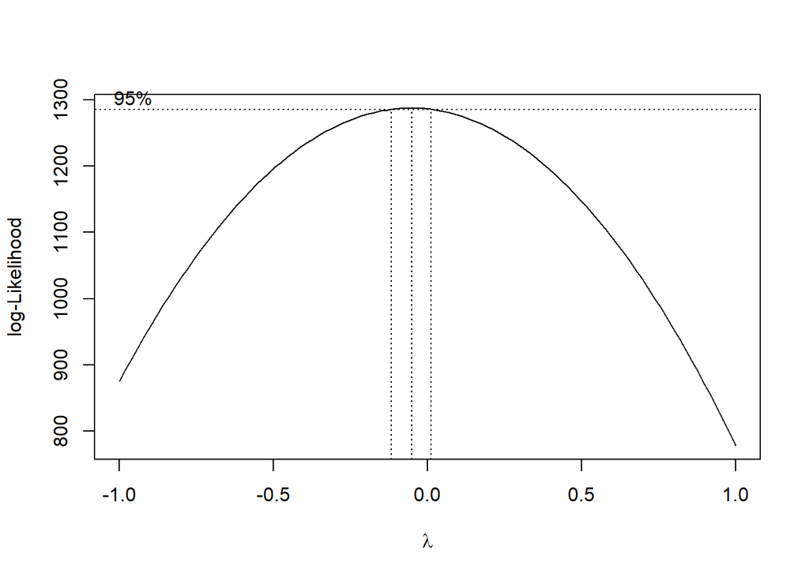

```r
#Plot Box-Cox
index <- seq(1:563)
bc = boxcox(train.ts~index, lambda = seq(-1,1,by=1))
```

```r
#Nilai Rounded Lambda
lambda <- bc$x[which.max(bc$y)]
lambda
```

```
## [1] -0.05050505
```

```r
#SK
bc$x[bc$y > max(bc$y) - 1/2 * qchisq(.95,1)]
```

```
## [1] -0.11111111 -0.09090909 -0.07070707 -0.05050505 -0.03030303 -0.01010101
## [7]  0.01010101
```

Plot Boxcox menunjukkan nilai *rounded value* ($\lambda$) optimum sebesar **-0.05050505** dan pada selang kepercayaan 95% nilai memiliki batas bawah **-0.11111111** dan batas atas **0.01010101**. Selang tersebut memuat nilai nol sehingga dapat dilakukan transformasi logaritmik.

```r
# Transformed data
transformasi <- log(train.ts)
```

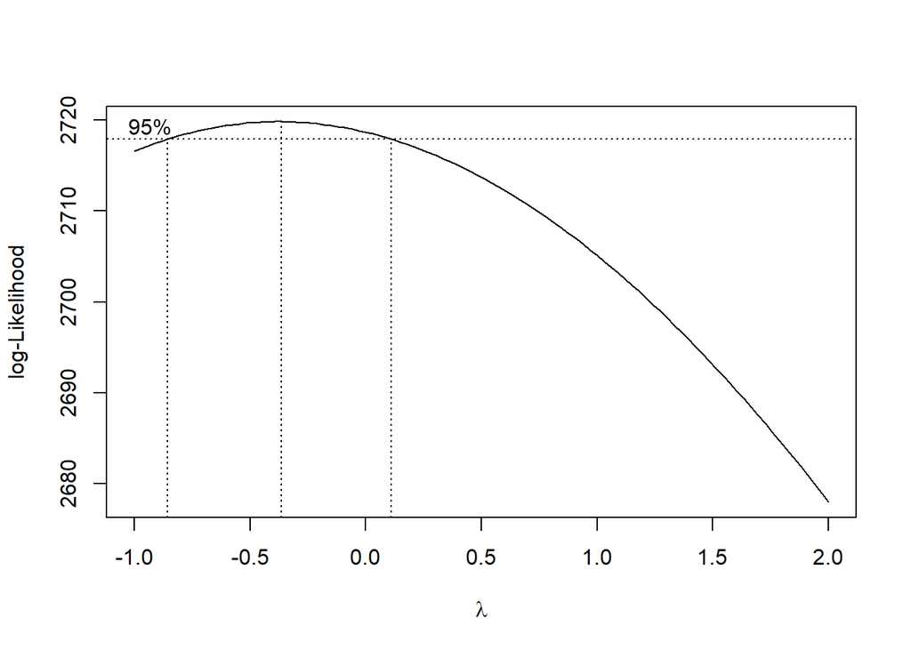

```r
#Plot Box-Cox
index <- seq(1:563)
bc = boxcox(transformasi~index, lambda = seq(-1,2,by=1))
```

```r
#Nilai Rounded Lambda
lambda <- bc$x[which.max(bc$y)]
lambda
```

```
## [1] -0.3636364
```

```r
#SK
bc$x[bc$y > max(bc$y) - 1/2 * qchisq(.95,1)]
```

```
##  [1] -0.84848485 -0.81818182 -0.78787879 -0.75757576 -0.72727273 -0.69696970
##  [7] -0.66666667 -0.63636364 -0.60606061 -0.57575758 -0.54545455 -0.51515152
## [13] -0.48484848 -0.45454545 -0.42424242 -0.39393939 -0.36363636 -0.33333333
## [19] -0.30303030 -0.27272727 -0.24242424 -0.21212121 -0.18181818 -0.15151515
## [25] -0.12121212 -0.09090909 -0.06060606 -0.03030303  0.00000000  0.03030303
## [31]  0.06060606  0.09090909
```

Plot Boxcox menunjukkan nilai *rounded value* ($\lambda$) optimum sebesar **-0.3636364** dan pada selang kepercayaan 95% nilai memiliki batas bawah **-0.84848485** dan batas atas **0.09090909**. Selang tersebut belum memuat nilai 1 sehingga belum stasioner dalam ragam dan perlu dilakukan transformasi lagi. Selang tersebut memuat nilai nol sehingga dapat dilakukan transformasi logaritmik.

```r
# Transformed data
transformasi2 <- log(transformasi)
```

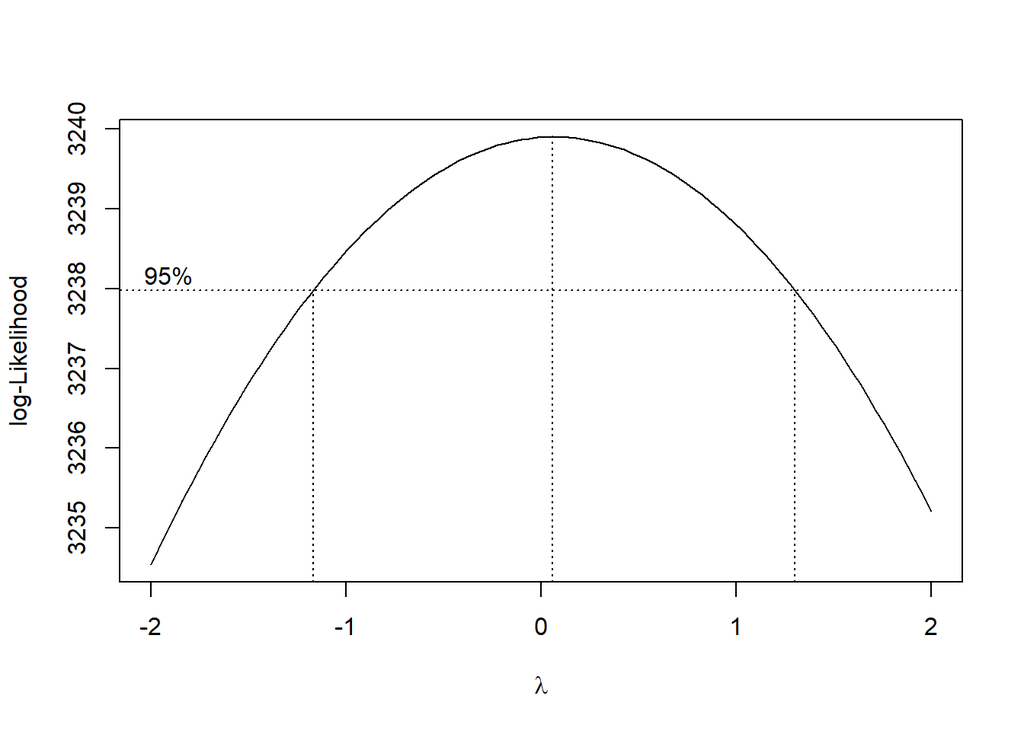

```r
#Plot Box-Cox
index <- seq(1:563)
bc = boxcox(transformasi2~index, lambda = seq(-2,2,by=1))
```

```r
#Nilai Rounded Lambda
lambda <- bc$x[which.max(bc$y)]
lambda
```

```
## [1] 0.06060606
```

```r
#SK
bc$x[bc$y > max(bc$y) - 1/2 * qchisq(.95,1)]
```

```
##  [1] -1.15151515 -1.11111111 -1.07070707 -1.03030303 -0.98989899 -0.94949495
##  [7] -0.90909091 -0.86868687 -0.82828283 -0.78787879 -0.74747475 -0.70707071
## [13] -0.66666667 -0.62626263 -0.58585859 -0.54545455 -0.50505051 -0.46464646
## [19] -0.42424242 -0.38383838 -0.34343434 -0.30303030 -0.26262626 -0.22222222
## [25] -0.18181818 -0.14141414 -0.10101010 -0.06060606 -0.02020202  0.02020202
## [31]  0.06060606  0.10101010  0.14141414  0.18181818  0.22222222  0.26262626
## [37]  0.30303030  0.34343434  0.38383838  0.42424242  0.46464646  0.50505051
## [43]  0.54545455  0.58585859  0.62626263  0.66666667  0.70707071  0.74747475
## [49]  0.78787879  0.82828283  0.86868687  0.90909091  0.94949495  0.98989899
## [55]  1.03030303  1.07070707  1.11111111  1.15151515  1.19191919  1.23232323
## [61]  1.27272727
```

Plot Boxcox menunjukkan nilai *rounded value* ($\lambda$) optimum sebesar **0.06060606** dan pada selang kepercayaan 95% nilai memiliki batas bawah **-1.15151515** dan batas atas **1.27272727**. Selang tersebut memuat nilai 1 sehingga hal ini menandakan data sudah stasioner dalam ragam dan ketidakstasioneran data dalam ragam telah berhasil tertangani.

### PLot Time Series

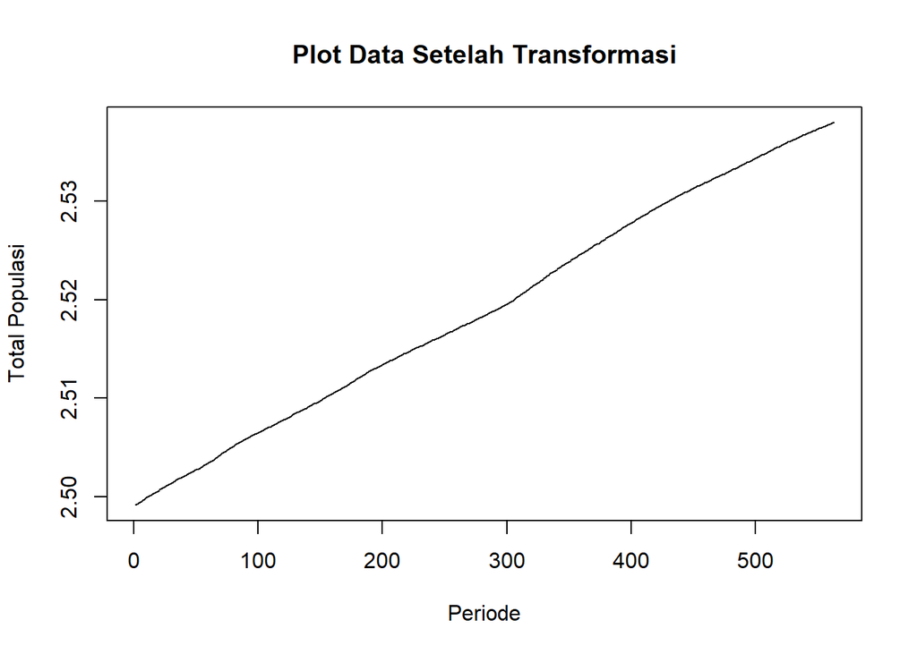

```r
plot.ts(transformasi2, lty=1, xlab="Periode", ylab="Total Populasi", main="Plot Data Setelah Transformasi")
```

#### Plot ACF

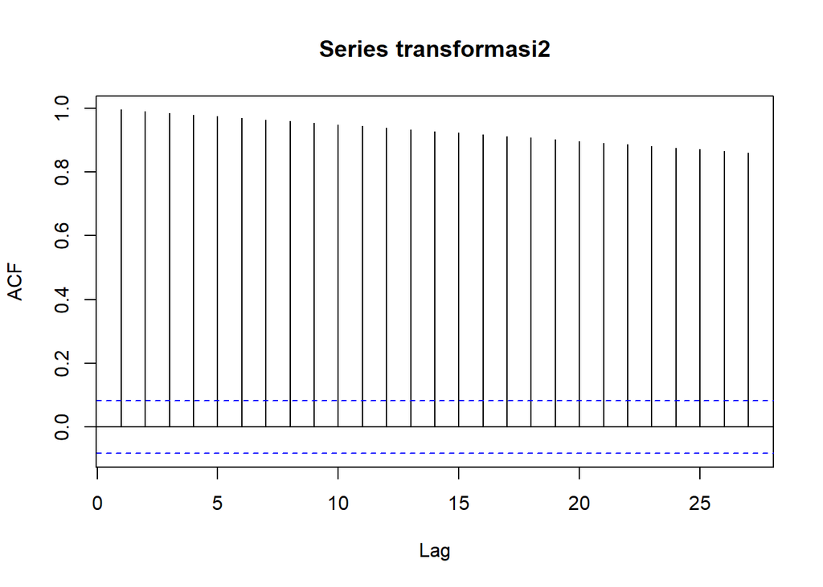

```r
acf(transformasi2)
```

Berdasarkan plot ACF, terlihat bahwa plot ACF data menurun secara perlahan (*tails of slowly*). Hal ini juga menjadi indikasi bahwa data tidak stasioner dalam rataan.

#### Uji ADF

```r
tseries::adf.test(transformasi2)
```

```
##
##  Augmented Dickey-Fuller Test
##
## data:  transformasi2
## Dickey-Fuller = -1.8398, Lag order = 8, p-value = 0.6461
## alternative hypothesis: stationary
```

$H_0$ : Data tidak stasioner dalam rataan

$H_1$ : Data stasioner dalam rataan

Berdasarkan uji ADF tersebut, didapat *p-value* sebesar 0.6461 yang lebih besar dari taraf nyata 5% sehingga tak tolak $H_0$ dan menandakan bahwa data tidak stasioner dalam rataan. Hal ini sesuai dengan hasil eksplorasi menggunakan plot time series dan plot ACF, sehingga ketidakstasioneran model kedepannya harus ditangani.

#### Plot Box-Cox

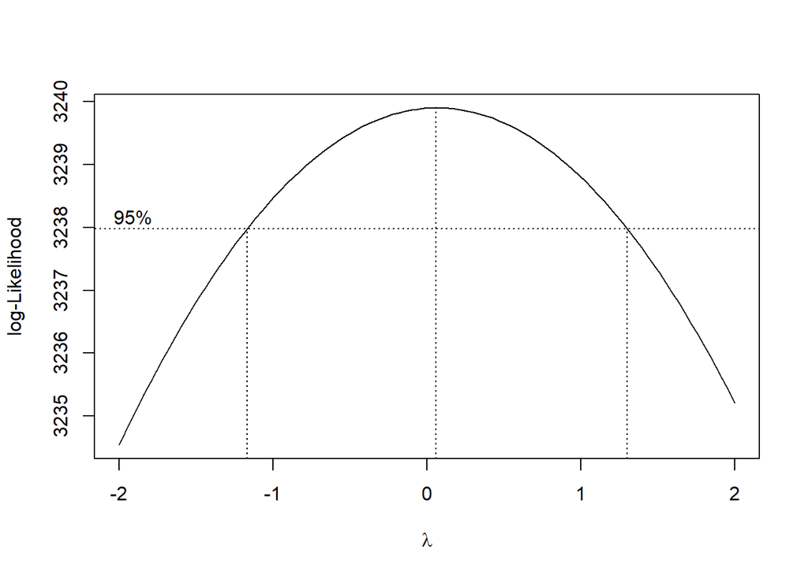

```r
index <- seq(1:563)
bc = boxcox(transformasi2~index, lambda = seq(-2,2,by=1))
```

```r
#Nilai Rounded Lambda
lambda <- bc$x[which.max(bc$y)]
lambda
```

```
## [1] 0.06060606
```

```r
#SK
bc$x[bc$y > max(bc$y) - 1/2 * qchisq(.95,1)]
```

```
##  [1] -1.15151515 -1.11111111 -1.07070707 -1.03030303 -0.98989899 -0.94949495
##  [7] -0.90909091 -0.86868687 -0.82828283 -0.78787879 -0.74747475 -0.70707071
## [13] -0.66666667 -0.62626263 -0.58585859 -0.54545455 -0.50505051 -0.46464646
## [19] -0.42424242 -0.38383838 -0.34343434 -0.30303030 -0.26262626 -0.22222222
## [25] -0.18181818 -0.14141414 -0.10101010 -0.06060606 -0.02020202  0.02020202
## [31]  0.06060606  0.10101010  0.14141414  0.18181818  0.22222222  0.26262626
## [37]  0.30303030  0.34343434  0.38383838  0.42424242  0.46464646  0.50505051
## [43]  0.54545455  0.58585859  0.62626263  0.66666667  0.70707071  0.74747475
## [49]  0.78787879  0.82828283  0.86868687  0.90909091  0.94949495  0.98989899
## [55]  1.03030303  1.07070707  1.11111111  1.15151515  1.19191919  1.23232323
## [61]  1.27272727
```

Plot Boxcox menunjukkan nilai *rounded value* ($\lambda$) optimum sebesar **0.06060606** dan pada selang kepercayaan 95% nilai memiliki batas bawah **-1.15151515** dan batas atas **1.27272727**. Selang tersebut memuat nilai satu sehingga dapat dikatakan bahwa data stasioner dalam ragam.

### Penanganan Ketidakstasioneran Data

### Differencing 1

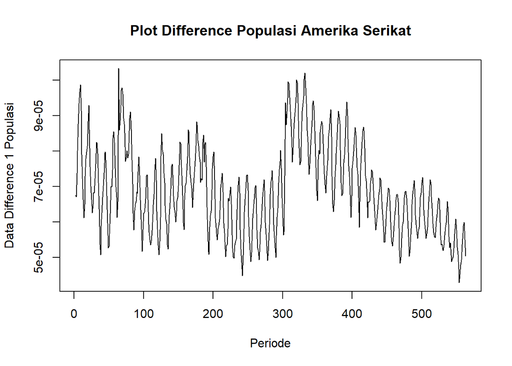

```r
train.diff<-diff(transformasi2,differences = 1)
plot.ts(train.diff, lty=1, xlab="Periode", ylab="Data Difference 1 Populasi", main="Plot Difference Populasi Amerika Serikat")
```

Berdasarkan plot data deret waktu, terlihat bahwa data belum stasioner dalam rataan.

#### Uji ADF

```r
tseries::adf.test(train.diff)
```

```
##
##  Augmented Dickey-Fuller Test
##
## data:  train.diff
## Dickey-Fuller = -2.0379, Lag order = 8, p-value = 0.5623
## alternative hypothesis: stationary
```

$H_0$ : Data tidak stasioner dalam rataan

$H_1$ : Data stasioner dalam rataan

Berdasarkan uji ADF tersebut, didapat *p-value* sebesar 0.5623 yang lebih besar dari taraf nyata 5% sehingga tak tolak $H_0$ atau data tidak stasioner dalam rataan. Hal ini sesuai dengan hasil eksplorasi menggunakan plot time series data difference 1 populasi.

### Differencing 2

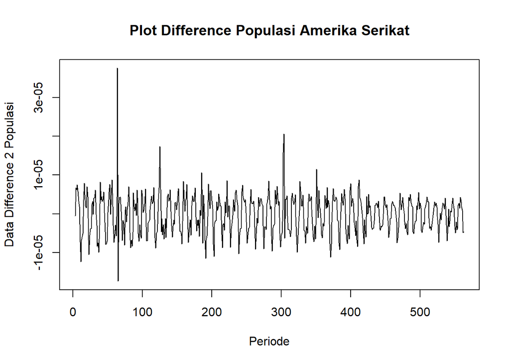

```r
train.diff2<-diff(transformasi2,differences = 2)
plot.ts(train.diff2, lty=1, xlab="Periode", ylab="Data Difference 2 Populasi", main="Plot Difference Populasi Amerika Serikat")
```

Berdasarkan plot data deret waktu, terlihat bahwa data sudah stasioner dalam rataan ditandai dengan data bergerak pada nilai tengah tertentu.

#### Plot ACF

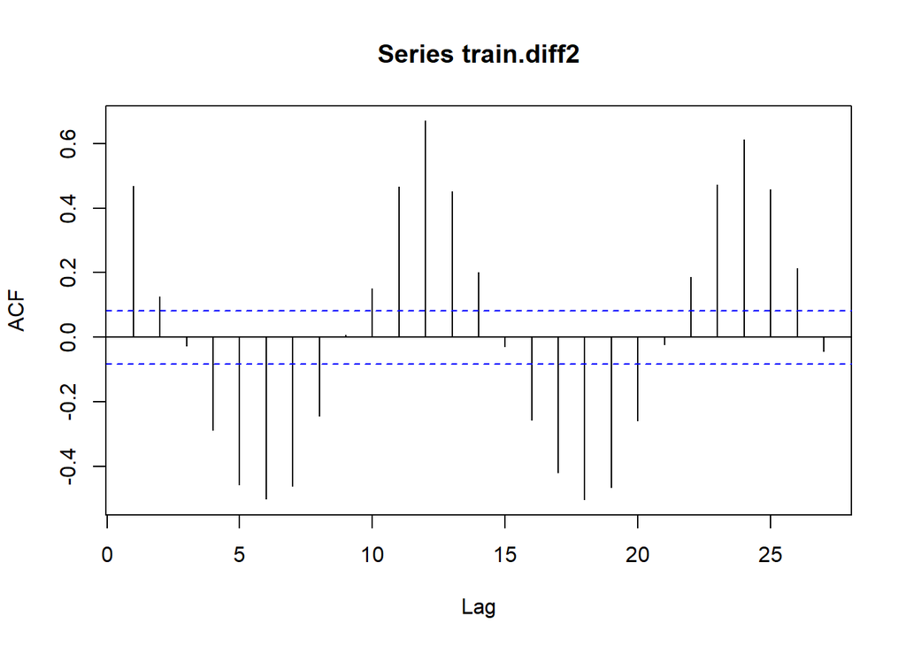

```r
acf(train.diff2)
```

#### Uji ADF

```r
tseries::adf.test(train.diff2)
```

```
##
##  Augmented Dickey-Fuller Test
##
## data:  train.diff2
## Dickey-Fuller = -16.992, Lag order = 8, p-value = 0.01
## alternative hypothesis: stationary
```

$H_0$ : Data tidak stasioner dalam rataan

$H_1$ : Data stasioner dalam rataan

Berdasarkan uji ADF tersebut, didapat *p-value* sebesar 0.01 yang lebih kecil dari taraf nyata 5% sehingga tolak $H_0$ atau data stasioner dalam rataan. Hal ini sesuai dengan hasil eksplorasi menggunakan plot time series dan plot ACF, sehingga dalam hal ini ketidakstasioneran data sudah berhasil ditangani dan dapat dilanjutkan ke pemodelan

### Identifikasi Model

#### Plot ACF

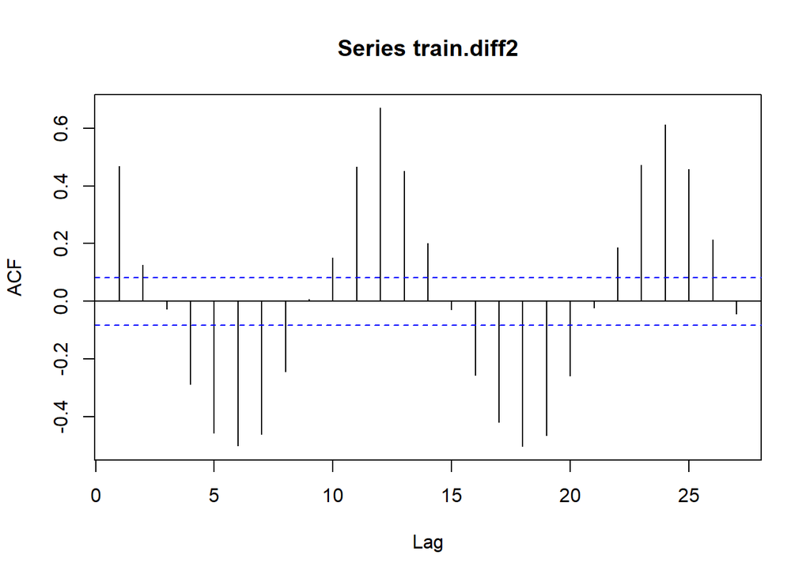

```r
acf(train.diff2)
```

#### Plot PACF

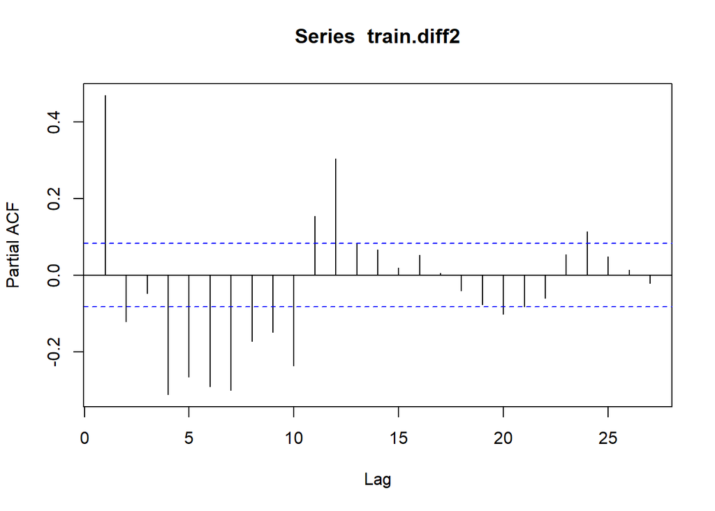

```r
pacf(train.diff2)
```

Jika baik plot ACF maupun plot PACF keduanya dianggap tails off, maka model yang terbentuk adalah ARIMA(2,2,2).

#### Plot EACF

```r
eacf(train.diff2)
```

```
## AR/MA
##   0 1 2 3 4 5 6 7 8 9 10 11 12 13
## 0 x x o x x x x x o x x  x  x  x
## 1 x x o x x o x x o o x  x  x  x
## 2 x o x o o o x o o o o  x  x  o
## 3 x x x x o o x o x x o  x  x  x
## 4 x x o x o o o o o x o  x  x  x
## 5 x x o x o o o o o x o  x  x  x
## 6 x x x x x o o o o o o  x  x  o
## 7 x x x x o o x o o o o  x  x  x
```

Identifikasi model menggunakan plot EACF dilakukan dengan melihat ujung segitiga pada pola segitiga nol. Dalam hal ini model tentatif yang terbentuk adalah ARIMA(2,2,3).

### Pendugaan Parameter Model Tentatif

#### ARIMA(0,2,2)

```r
model1.2da=Arima(train.diff2, order=c(0,2,2),method="ML")
summary(model1.2da) #AIC=-12043.08
```

```
## Series: train.diff2
## ARIMA(0,2,2)
##
## Coefficients:
##          ma1     ma2
##       -1.276  0.2760
## s.e.   0.051  0.0508
##
## sigma^2 = 2.526e-11:  log likelihood = 6024.54
## AIC=-12043.08   AICc=-12043.03   BIC=-12030.1
##
## Training set error measures:
##                         ME         RMSE          MAE      MPE     MAPE     MASE
## Training set -2.305339e-08 5.008469e-06 3.447738e-06 67.39068 196.1685 1.018248
##                    ACF1
## Training set 0.04530302
```

```r
lmtest::coeftest(model1.2da) #seluruh parameter signifikan
```

```
##
## z test of coefficients:
##
##      Estimate Std. Error  z value  Pr(>|z|)
## ma1 -1.276004   0.050970 -25.0344 < 2.2e-16 ***
## ma2  0.276005   0.050778   5.4355 5.464e-08 ***
## ---
## Signif. codes:  0 '***' 0.001 '**' 0.01 '*' 0.05 '.' 0.1 ' ' 1
```

#### ARIMA(2,2,0)

```r
model2.2da=Arima(train.diff2, order=c(2,2,0),method="ML")
summary(model2.2da) #AIC=-11857.88
```

```
## Series: train.diff2
## ARIMA(2,2,0)
##
## Coefficients:
##           ar1      ar2
##       -0.7451  -0.4904
## s.e.   0.0369   0.0368
##
## sigma^2 = 3.558e-11:  log likelihood = 5931.94
## AIC=-11857.88   AICc=-11857.84   BIC=-11844.9
##
## Training set error measures:
##                         ME         RMSE          MAE      MPE     MAPE     MASE
## Training set -2.964463e-08 5.943741e-06 3.967817e-06 54.22146 264.2443 1.171847
##                    ACF1
## Training set -0.1169458
```

```r
lmtest::coeftest(model2.2da) #seluruh parameter signifikan
```

```
##
## z test of coefficients:
##
##      Estimate Std. Error z value  Pr(>|z|)
## ar1 -0.745059   0.036862 -20.212 < 2.2e-16 ***
## ar2 -0.490393   0.036803 -13.325 < 2.2e-16 ***
## ---
## Signif. codes:  0 '***' 0.001 '**' 0.01 '*' 0.05 '.' 0.1 ' ' 1
```

#### ARIMA(2,2,2)

```r
model3.2da=Arima(train.diff2, order=c(2,2,2),method="ML")
summary(model3.2da) #AIC=-12056.07
```

```
## Series: train.diff2
## ARIMA(2,2,2)
##
## Coefficients:
##           ar1      ar2      ma1      ma2
##       -0.4564  -0.2548  -0.7456  -0.2544
## s.e.   0.1886   0.0465   0.1955   0.1955
##
## sigma^2 = 2.46e-11:  log likelihood = 6033.03
## AIC=-12056.07   AICc=-12055.96   BIC=-12034.44
##
## Training set error measures:
##                         ME         RMSE          MAE      MPE     MAPE
## Training set -2.443503e-08 4.932796e-06 3.380669e-06 69.62112 196.9431
##                   MASE         ACF1
## Training set 0.9984399 -0.001252524
```

```r
lmtest::coeftest(model3.2da) #terdapat parameter tidak signifikan
```

```
##
## z test of coefficients:
##
##      Estimate Std. Error z value  Pr(>|z|)
## ar1 -0.456423   0.188593 -2.4201 0.0155143 *
## ar2 -0.254806   0.046507 -5.4789 4.279e-08 ***
## ma1 -0.745610   0.195525 -3.8134 0.0001371 ***
## ma2 -0.254385   0.195475 -1.3014 0.1931309
## ---
## Signif. codes:  0 '***' 0.001 '**' 0.01 '*' 0.05 '.' 0.1 ' ' 1
```

#### ARIMA(2,2,3)

```r
model4.2da=Arima(train.diff2, order=c(2,2,3),method="ML")
summary(model4.2da) #AIC=-12179.38
```

```
## Series: train.diff2
## ARIMA(2,2,3)
##
## Coefficients:
##           ar1     ar2      ma1      ma2     ma3
##       -0.1385  0.2160  -1.3240  -0.3498  0.6748
## s.e.   0.1090  0.0691   0.0958   0.1901  0.0950
##
## sigma^2 = 1.937e-11:  log likelihood = 6095.69
## AIC=-12179.38   AICc=-12179.23   BIC=-12153.42
##
## Training set error measures:
##                        ME         RMSE          MAE      MPE     MAPE      MASE
## Training set 4.020687e-08 4.373071e-06 3.054827e-06 81.32248 125.8134 0.9022065
##                     ACF1
## Training set 0.005048139
```

```r
lmtest::coeftest(model4.2da) #terdapat parameter tidak signifikan
```

```
##
## z test of coefficients:
##
##      Estimate Std. Error  z value  Pr(>|z|)
## ar1 -0.138542   0.108960  -1.2715  0.203556
## ar2  0.216024   0.069088   3.1268  0.001767 **
## ma1 -1.323988   0.095758 -13.8264 < 2.2e-16 ***
## ma2 -0.349788   0.190066  -1.8404  0.065717 .
## ma3  0.674761   0.095031   7.1004 1.244e-12 ***
## ---
## Signif. codes:  0 '***' 0.001 '**' 0.01 '*' 0.05 '.' 0.1 ' ' 1
```

Berdasarkan pendugaan parameter di atas, nilai AIC terkecil dan seluruh parameter signifikan dimiliki oleh model ARIMA(0,2,2) dengan nilai AIC sebesar -12043.08.

### Analisis Sisaan

Model terbaik hasil identifikasi kemudian dicek asumsi sisaannya. Sisaan model ARIMA harus memenuhi asumsi normalitas, kebebasan sisaan, dan kehomogenan ragam. Diagnostik model dilakukan secara eksplorasi dan uji formal.

#### Eksplorasi Sisaan

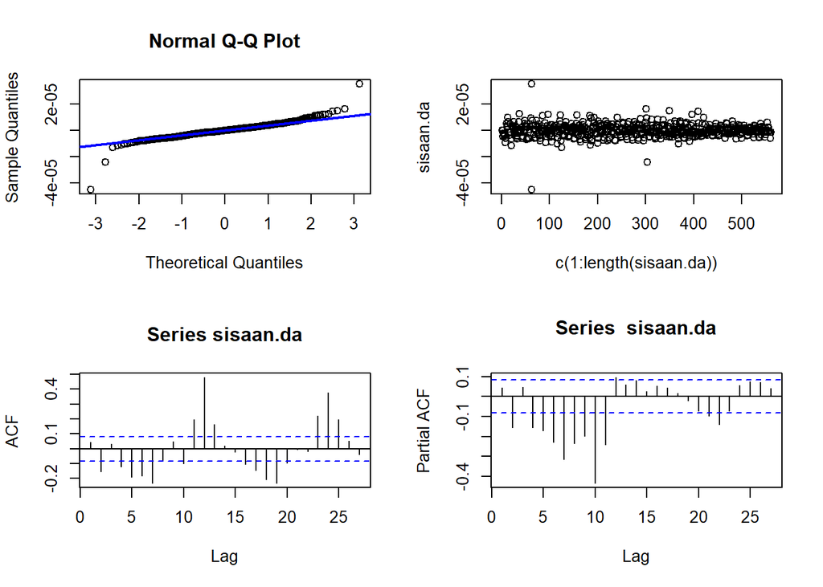

```r
#Eksplorasi
sisaan.da <- model1.2da$residuals
par(mfrow=c(2,2))
qqnorm(sisaan.da)
qqline(sisaan.da, col = "blue", lwd = 2)
plot(c(1:length(sisaan.da)),sisaan.da)
acf(sisaan.da)
pacf(sisaan.da)
```

```r
par(mfrow = c(1,1))
```

Berdasarkan plot kuantil-kuantil normal, secara eksplorasi ditunjukkan sisaan tidak menyebar normal ditandai dengan titik titik yang cenderung tidak mengikuti garis. Kemudian dapat dilihat juga lebar pita sisaan yang cenderung tidak sama menandakan bahwa sisaan memiliki ragam yang heterogen. Plot ACF dan PACF sisaan ARIMA(0,2,2) signifikan pada lag ke-2 sehingga sisaan tidak saling bebas. Kondisi ini akan diuji lebih lanjut dengan uji formal.

#### Uji Formal

```r
#1) Sisaan Menyebar Normal
ks.test(sisaan.da,"pnorm")  #tak tolak H0 > sisaan menyebar normal
```

```
##
##  Asymptotic one-sample Kolmogorov-Smirnov test
##
## data:  sisaan.da
## D = 0.49999, p-value < 2.2e-16
## alternative hypothesis: two-sided
```

Selain dengan eksplorasi, asumsi tersebut dapat diuji menggunakan uji formal. Pada tahapan ini uji formal yang digunakan untuk normalitas adalah uji Kolmogorov-Smirnov (KS). Hipotesis pada uji KS adalah sebagai berikut.

$H_0$ : Sisaan menyebar normal

$H_1$ : Sisaan tidak menyebar normal

Berdasarkan uji KS tersebut, didapat *p-value* sebesar < 2.2e-16 yang kurang dari taraf nyata 5% sehingga tolak $H_0$ dan menandakan bahwa sisaan tidak menyebar normal. Hal ini sesuai dengan hasil eksplorasi menggunakan plot kuantil-kuantil normal.

```r
#2) Sisaan saling bebas/tidak ada autokorelasi
Box.test(sisaan.da, type = "Ljung")  #tak tolak H0 > sisaan saling bebas
```

```
##
##  Box-Ljung test
##
## data:  sisaan.da
## X-squared = 1.1575, df = 1, p-value = 0.282
```

Selanjutnya akan dilakukan uji formal untuk kebebasan sisaan menggunakan uji Ljung-Box. Hipotesis yang digunakan adalah sebagai berikut.

$H_0$ : Sisaan saling bebas

$H_1$ : Sisaan tidak tidak saling bebas

Berdasarkan uji Ljung-Box tersebut, didapat *p-value* sebesar 0.282 yang lebih besar dari taraf nyata 5% sehingga tak tolak $H_0$ dan menandakan bahwa sisaan saling bebas. Hal ini berbeda dengan eksplorasi.

```r
#3) Sisaan homogen
Box.test((sisaan.da)^2, type = "Ljung")  #tak tolak H0 > sisaan homogen
```

```
##
##  Box-Ljung test
##
## data:  (sisaan.da)^2
## X-squared = 102.14, df = 1, p-value < 2.2e-16
```

Hipotesis yang digunakan untuk uji kehomogenan ragam adalah sebagai berikut.

$H_0$ : Ragam sisaan homogen

$H_1$ : Ragam sisaan tidak homogen

Berdasarkan uji Ljung-Box terhadap sisaan kuadrat tersebut, didapat *p-value* sebesar < 2.2e-16 yang kurang dari taraf nyata 5% sehingga tolak $H_0$ dan menandakan bahwa ragam sisaan tidak homogen.

```r
#4) Nilai tengah sisaan sama dengan nol
t.test(sisaan.da, mu = 0, conf.level = 0.95)  #tak tolak h0 > nilai tengah sisaan sama dengan 0
```

```
##
##  One Sample t-test
##
## data:  sisaan.da
## t = -0.10893, df = 560, p-value = 0.9133
## alternative hypothesis: true mean is not equal to 0
## 95 percent confidence interval:
##  -4.387668e-07  3.926601e-07
## sample estimates:
##     mean of x
## -2.305339e-08
```

Terakhir, dengan uji-t, akan dicek apakah nilai tengah sisaan sama dengan nol. Hipotesis yang diujikan sebagai berikut.

$H_0$ : nilai tengah sisaan sama dengan 0

$H_1$ : nilai tengah sisaan tidak sama dengan 0

Berdasarkan uji-ttersebut, didapat *p-value* sebesar 0.9133 yang lebih besar dari taraf nyata 5% sehingga tak tolak $H_0$ dan menandakan bahwa nilai tengah sisaan sama dengan nol.

### Overfitting

Tahapan selanjutnya adalah overfitting dilakukan dengan menaikkan orde AR(p) dan MA(q) dari model ARIMA(0,2,2) untuk melihat apakah terdapat model lain yang lebih baik dari model saat ini. Kandidat model overfitting adalah ARIMA(1,2,2) dan ARIMA(0,2,3).

```r
model5.2da=Arima(train.diff2, order=c(1,2,2),method="ML")
summary(model5.2da) #AIC=-12173.44
```

```
## Series: train.diff2
## ARIMA(1,2,2)
##
## Coefficients:
##          ar1      ma1     ma2
##       0.4772  -1.9982  0.9987
## s.e.  0.0376   0.0095  0.0095
##
## sigma^2 = 1.966e-11:  log likelihood = 6090.72
## AIC=-12173.44   AICc=-12173.37   BIC=-12156.13
##
## Training set error measures:
##                        ME         RMSE          MAE      MPE    MAPE      MASE
## Training set 4.273391e-08 4.413776e-06 3.085967e-06 80.86889 127.175 0.9114033
##                    ACF1
## Training set 0.05420992
```

```r
lmtest::coeftest(model5.2da) #seluruh parameter signifikan
```

```
##
## z test of coefficients:
##
##       Estimate Std. Error  z value  Pr(>|z|)
## ar1  0.4772254  0.0376025   12.691 < 2.2e-16 ***
## ma1 -1.9982350  0.0094759 -210.874 < 2.2e-16 ***
## ma2  0.9986587  0.0094724  105.428 < 2.2e-16 ***
## ---
## Signif. codes:  0 '***' 0.001 '**' 0.01 '*' 0.05 '.' 0.1 ' ' 1
```

#### ARIMA(0,2,3)

```r
model6.2da=Arima(transformasi2, order=c(0,2,3),method="ML")
summary(model6.2da) #AIC=-12252.71
```

```
## Series: transformasi2
## ARIMA(0,2,3)
##
## Coefficients:
##          ma1     ma2     ma3
##       0.5231  0.1688  0.1486
## s.e.  0.0414  0.0448  0.0455
##
## sigma^2 = 2.24e-08:  log likelihood = 6130.35
## AIC=-12252.71   AICc=-12252.64   BIC=-12235.39
##
## Training set error measures:
##                         ME         RMSE          MAE           MPE         MAPE
## Training set -3.982189e-06 0.0001490102 1.095657e-05 -0.0001593214 0.0004375728
##                   MASE       ACF1
## Training set 0.1583165 -0.3021802
```

```r
lmtest::coeftest(model6.2da) #seluruh parameter signifikan
```

```
##
## z test of coefficients:
##
##     Estimate Std. Error z value  Pr(>|z|)
## ma1 0.523132   0.041358 12.6490 < 2.2e-16 ***
## ma2 0.168800   0.044797  3.7681 0.0001645 ***
## ma3 0.148580   0.045538  3.2628 0.0011033 **
## ---
## Signif. codes:  0 '***' 0.001 '**' 0.01 '*' 0.05 '.' 0.1 ' ' 1
```